# Indeed Product Scientist Homework

Michael Lee

August 25, 2017

## Indeed sales leads

The provided dataset on sales leads contained over 70,000 observations and 9 variables. There were many missing data fields that needed to be addressed prior to analysis. For example, empty fields in the “revenue” column appear as “NA”. First, the dataset was read into R-studio and the variables were reviewed. I then replace the “NA” fields with 0

```r
dataset <- read.csv("C:/Users/cwbishop/Documents/Github/Indeed/homework_data_set.csv")
names(dataset)
```

```
##  [1] "X"                      "advertiser_id"
##  [3] "assigned"               "date_assignment_starts"
##  [5] "date_assignment_ends"   "first_revenue_date"
##  [7] "date_created"           "age"
##  [9] "assign_days"            "revenue"
```

```r
dataset$revenue[is.na(dataset$revenue)]=0
```

## Question 1

“How many leads are represented in this dataset? Please describe both the assigned and unassigned populations. What is the average revenue of each group?”

Each lead is uniquely numbered and the dataset is ordered according to the lead number. If the data numbering were perfect, one could use the last number (77890) as a count of the number of leads. However, since the first lead starts on “0” and to account for potential data entry errors, a count of the number of rows would be more appropriate.

```r
nleads <- nrow(dataset)
print(nleads)
```

```
## [1] 77891
```

To count the number of leads that were assigned or unassigned, we can use the table function on the dataset grouped by the “assigned” variable.

```r
nleads_assign <- table(dataset$assigned)
names(nleads_assign) <- c("Not assigned","Assigned")
print(nleads_assign)
```

```
## Not assigned     Assigned
##        40812        37079
```

To further describe the assigned and unassigned population, we first subset the dataset by the “assigned” variable

```r
data_assigned <- dataset[dataset$assigned==1,]
data_unassigned <- dataset[dataset$assigned==0,]
```

To calculate the average revenue in each group, I use the aggregate-mean function on the dataset, aggregating by the assigned variable. Since we are average revenue, it was critical to assign “0” to the missing revenue fields, which I assume represents no revenue was generated for that lead.

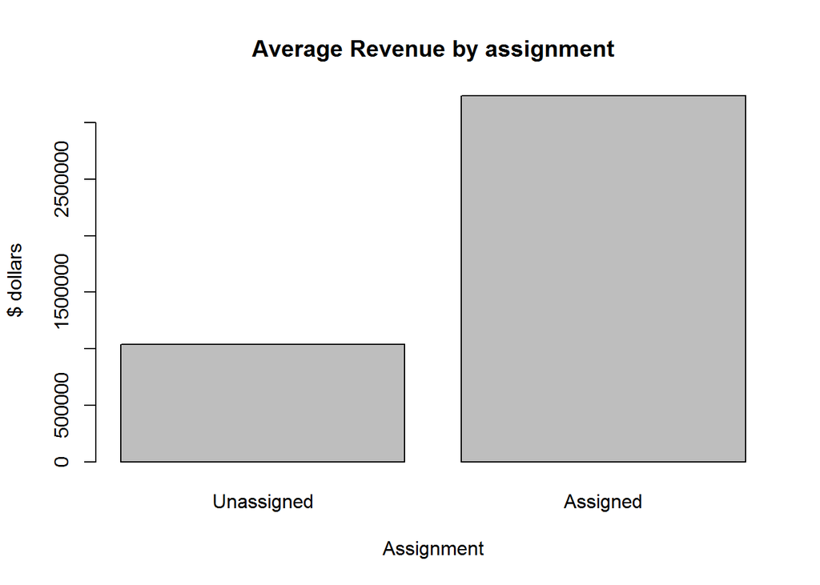

```r
avg_revenue <- as.numeric(aggregate(revenue~assigned,dataset,FUN=mean)[2][,1])
names(avg_revenue) <- c("Unassigned","Assigned")

barplot(avg_revenue,main="Average Revenue by assignment", xlab="Assignment", ylab="$ dollars")
```

## Question 2

“What are the most important metrics to consider in this data set? Why?” There are 9 variables in the dataset. The most important variables in regard to the questions asked are 1) “revenue” is the dependent variable (outcome), 2) “assigned” will tell us if assigning leads is effective, 3) “age” will be neccessary to determine a relationship between account age and revenue.

## Question 3

“Analyze any existing relationship between account age and revenue, through visualization and/or other means.” Plotting Revenue by age, it is difficult to visually assess a relationship because there a majority of the leads result in 0 revenue, and there are over 70,000 data points in the dataset. The first plot shows revenue by age of account.

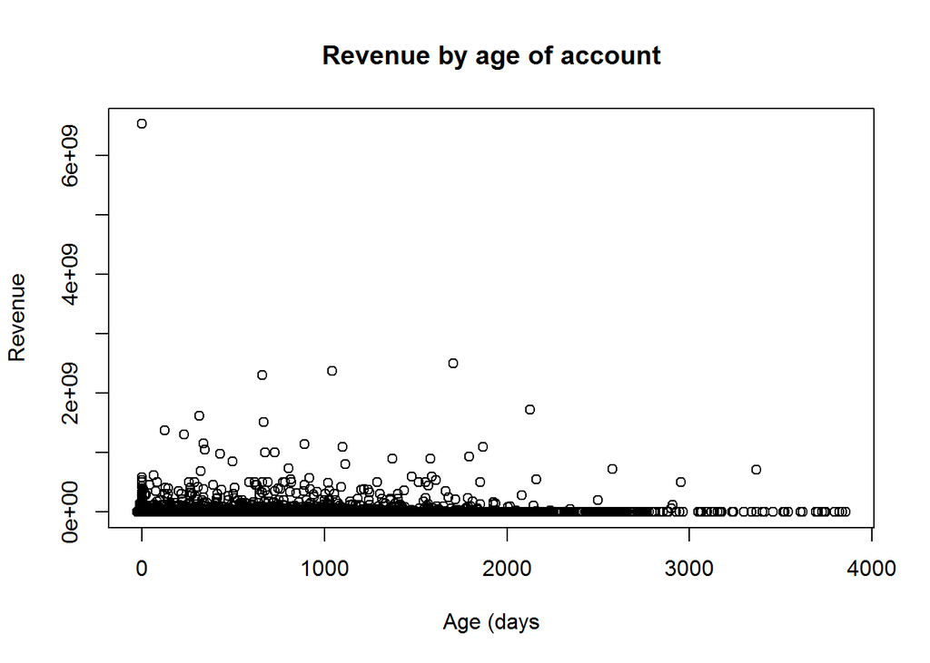

```r
plot(dataset$age,dataset$revenue, main="Revenue by age of account", ylab="Revenue", xlab="Age (days")
```

```r
dataset <- dataset[order(dataset$age),]
dataset$rev_cumsum <- cumsum(dataset$revenue)
```

To assess the relationship between account age and revenue, I converted revenue into a cumulative sum ordered by age. Here, we can see that almost a third of the revenue producing leads occur very close to the date they are created. The leads over time continue to lead to revenue until about 2000 days, where the revenue plateus.

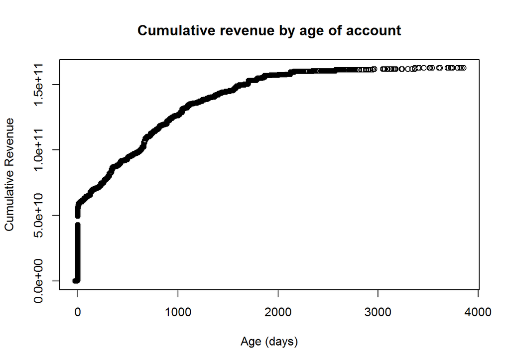

```r
plot(dataset$age,dataset$rev_cumsum, main="Cumulative revenue by age of account",ylab="Cumulative Revenue", xlab="Age (days)")
```

To examine the incremental value from assigning a lead to the sales team, I used linear regression.

```r
rev_mod <- lm(dataset$revenue~dataset$assigned)
summary(rev_mod)
```

```
##
## Call:
## lm(formula = dataset$revenue ~ dataset$assigned)
##
## Residuals:
##        Min         1Q     Median         3Q        Max
##   -3238846   -3238846   -1039001   -1039001 6532751999
##
## Coefficients:
##                  Estimate Std. Error t value Pr(>|t|)
## (Intercept)       1039001     184497   5.632 1.79e-08 ***
## dataset$assigned  2199845     267404   8.227  < 2e-16 ***
## ---
## Signif. codes:  0 '***' 0.001 '**' 0.01 '*' 0.05 '.' 0.1 ' ' 1
##
## Residual standard error: 37270000 on 77889 degrees of freedom
## Multiple R-squared:  0.0008682,  Adjusted R-squared:  0.0008553
## F-statistic: 67.68 on 1 and 77889 DF,  p-value: < 2.2e-16
```

```r
all_mod <- lm(dataset$revenue~dataset$advertiser_id+dataset$assigned+as.integer(dataset$date_assignment_starts)+as.integer(dataset$date_assignment_ends)+as.integer(dataset$first_revenue_date)+as.integer(dataset$date_created)+dataset$age+dataset$assign_days)
summary(all_mod)
```

```
##
## Call:
## lm(formula = dataset$revenue ~ dataset$advertiser_id + dataset$assigned +
##     as.integer(dataset$date_assignment_starts) + as.integer(dataset$date_assignment_ends) +
##     as.integer(dataset$first_revenue_date) + as.integer(dataset$date_created) +
##     dataset$age + dataset$assign_days)
##
## Residuals:
##        Min         1Q     Median         3Q        Max
##  -33651561    -908724    -344760     252986 6513602134
##
## Coefficients:
##                                              Estimate Std. Error t value
## (Intercept)                                -3.074e+07  8.390e+06  -3.664
## dataset$advertiser_id                       1.674e-01  1.637e-01   1.023
## dataset$assigned                            1.158e+06  4.307e+05   2.689
## as.integer(dataset$date_assignment_starts)  4.267e+05  2.154e+05   1.981
## as.integer(dataset$date_assignment_ends)   -1.357e+02  3.177e+02  -0.427
## as.integer(dataset$first_revenue_date)      1.311e+04  3.382e+02  38.772
## as.integer(dataset$date_created)            1.359e+04  4.498e+03   3.020
## dataset$age                                 1.574e+04  3.656e+03   4.307
## dataset$assign_days                         3.374e+03  1.117e+04   0.302
##                                            Pr(>|t|)
## (Intercept)                                0.000249 ***
## dataset$advertiser_id                      0.306435
## dataset$assigned                           0.007165 **
## as.integer(dataset$date_assignment_starts) 0.047576 *
## as.integer(dataset$date_assignment_ends)   0.669363
## as.integer(dataset$first_revenue_date)      < 2e-16 ***
## as.integer(dataset$date_created)           0.002526 **
## dataset$age                                1.66e-05 ***
## dataset$assign_days                        0.762570
## ---
## Signif. codes:  0 '***' 0.001 '**' 0.01 '*' 0.05 '.' 0.1 ' ' 1
##
## Residual standard error: 36900000 on 77882 degrees of freedom
## Multiple R-squared:  0.02087,    Adjusted R-squared:  0.02077
## F-statistic: 207.5 on 8 and 77882 DF,  p-value: < 2.2e-16
```

```r
data_assigned <- data_assigned[order(data_assigned$age),]
data_unassigned <- data_unassigned[order(data_unassigned$age),]
data_assigned$rev_cumsum <- cumsum(data_assigned$revenue)
data_unassigned$rev_cumsum <- cumsum(data_unassigned$revenue)
```